# Dynamic exposure modelling practical

You should open RStudio and copy+paste the code chunks (grey boxes of code) from below into your own script as you go through the pratical. Feel free to make changes if you want to - it’s the best way to learn. I suggest you make notes in your own script as you go to refer to later. You can make notes in R by putting a hashtag before them.

At a few places during the practical, there are some questions for you to answer, and a form for you to put them in.

At the end of the document there is a short task for you to try on your own; once you have done it please send your result and the code you used to make it, to james.d.smith@kcl.ac.uk. This is not assessed, but I will send you back some feedback and tips on it.

## Set-up

Start with a clean R environment, and load some libraries (sometimes called ‘packages’) that we are going to need. If a library doesn’t load (‘activate’), it’s probably because you don’t have it installed. You can run commands in the Console section of R studio such as ( `install.packages('raster')` ) to fix that. You can think of libraries/packages as add-ons that enhance the things R can do.

```r
rm(list = ls())                   # This clear the environment of any variables, old plots, that kind of thing.

library(raster,    quietly =TRUE)   # We will need this to deal with the air quality data
library(stplanr,   quietly =TRUE)   # We will use this to calculate routes between places
library(tidyverse, quietly =TRUE)   # The tidyverse is a group of R packages that are useful in general data analysis
library(sf,        quietly =TRUE)   # SF stands for 'simple features', it's a useful package for working with spatial data
```

## Routing

#### Decide on a route

```r
start    <- c(-0.112327, 51.505747)
end      <- c(-0.137143, 51.515080)
```

What is the latitude and longitude of Greenwich observatory? [Put your answers into this form](https://goo.gl/forms/ndJZ1hAgCviAPgsG3).

#### Calculate the route

We now use these start and end variables, within a function called `route_osrm()` which is from the `stplanr` R package. This package was developed to allow interaction between R, and the OpenStreetMap routing system. We can use it to say ‘tell me how to get from one location to another’. Only a driving mode is available by default.

```r
route <- route_osrm(from=start, to=end)  # This gets the route

route  <- st_as_sf(route)                # Change the route from a 'sp' object to 'sf'.
```

If you wanted to explore other transport modes you could look at using the function `route_transportapi_public()` instead of `route_osrm()`. It allows you to add an additional parameter of `mode = "__modehere__` where `__modehere__` is one of ‘bus’, ‘train’ or ‘tube’. Find the PDF manual for `stplanr`, and the name of the main author. Write your answer [into the form](https://goo.gl/forms/ndJZ1hAgCviAPgsG3).

Once the above code has run, you will have a route between FWB and Brewdog stored as a variable called `route`. If you type `route` into your R console you should see something like this. Have a look at what it shows, and what each field is telling you.

```r
route
```

```
## Simple feature collection with 1 feature and 2 fields
## geometry type:  LINESTRING
## dimension:      XY
## bbox:           xmin: -0.13732 ymin: 51.50447 xmax: -0.11205 ymax: 51.51531
## epsg (SRID):    4326
## proj4string:    +proj=longlat +datum=WGS84 +no_defs
##   distance duration                       geometry
## 1   2985.7    731.7 LINESTRING (-0.11205 51.505...
```

#### Plot the route

You can make a very basic map of the route using the `ggplot2` package as below. Note that there are many others ways of doing this.

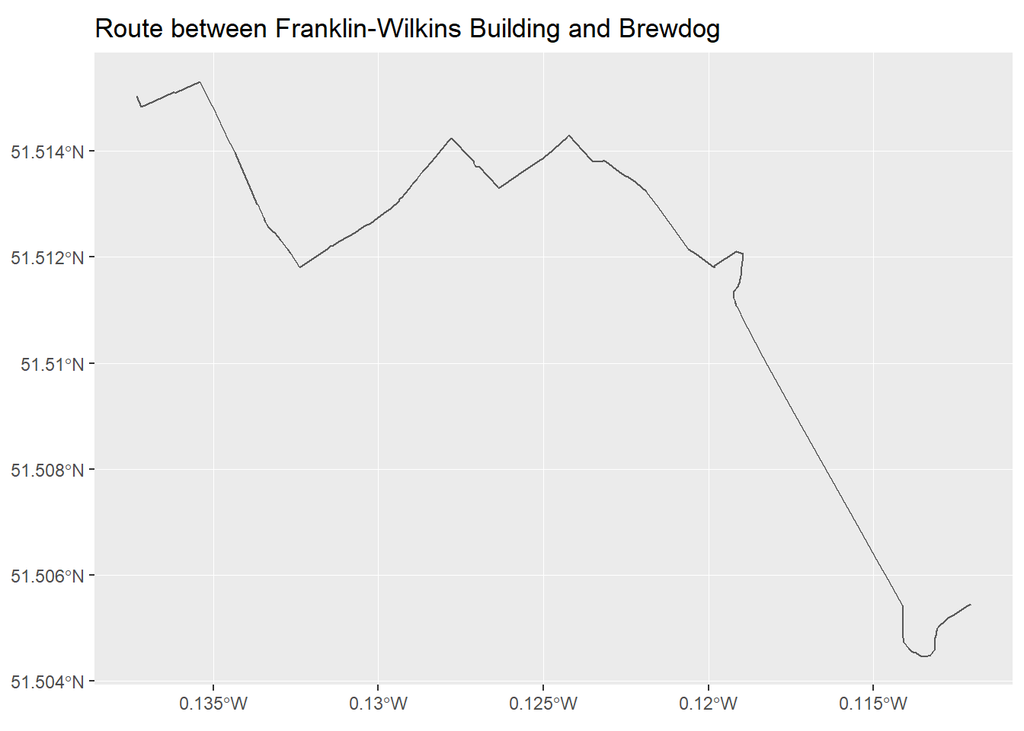

```r
ggplot() +
  geom_sf(data = route) +
  ggtitle('Route between Franklin-Wilkins Building and Brewdog')
```

## Air quality

#### Import air quality

Now that we have a route between the two locations we need some air quality data. In 2016 the modelling team undertook a large project for the [Greater London Authority](https://en.wikipedia.org/wiki/Greater_London_Authority) (The GLA) to produce maps and data on air quality in London. The outputs are available online for public use, and those are the data we are going to use. [Have a quick read through this webpage before we continue](https://data.london.gov.uk/dataset/london-atmospheric-emissions-inventory-2013). What are the years that the LAEI covers? [Write your answers into the form](https://goo.gl/forms/ndJZ1hAgCviAPgsG3).

Once you have looked through the site, download the ZIP file called `4.1. Concentrations LAEI 2013 Update`, extract the folder, and put the folder and files somewhere sensible on your computer. Now import the filed called `PostLAEI2013_2013_NO2.asc` like this (You will need to change the path so that it is specific to your computer).

```r
no2_2013     <- raster('C:/Users/stwb3498/Downloads/4.1. Concentrations LAEI 2013 Update/4.1. Concentrations LAEI 2013 Update/2013/ASCII/PostLAEI2013_2013_NO2.asc')
```

Type `no2_2013` into your console and you will be able to see information about the raster file you have imported.

```r
no2_2013
```

```
## class       : RasterLayer
## dimensions  : 2556, 3027, 7737012  (nrow, ncol, ncell)
## resolution  : 20, 20  (x, y)
## extent      : 501450, 561990, 152330, 203450  (xmin, xmax, ymin, ymax)
## coord. ref. : NA
## data source : C:\Users\stwb3498\Downloads\4.1. Concentrations LAEI 2013 Update\4.1. Concentrations LAEI 2013 Update\2013\ASCII\PostLAEI2013_2013_NO2.asc
## names       : PostLAEI2013_2013_NO2
```

You will see above that the `coord.ref` field of the raster object is empty (NA). Hopefully you remember how important coordinate reference systems (CRS’s) are from my lecture in the Air Quality Data Analysis module! The field is empty because although R has succesfully imported the data, it does not know what coordinate reference system it is. From experience I know that the system for this dataset is British National Grid, which is CRS code 27700. Most UK data is either codes 4326 or 27700. The R code below assigns the CRS of 27700 to the `no2_2013` object.

```r
latlong                 <- "+init=epsg:4326"
ukgrid                  <- "+init=epsg:27700"

proj4string(no2_2013)   <- CRS(ukgrid)
```

#### Plot air quality

You can plot your `no2_2013` raster object using the `plot()` command. As with many things in R, there are often multiple commands to do similar things, each achieving slightly different results. For example we could also have used the `levelplot(no2_2013)` command from the `rasterVis` package to view the data - ([Here’s how it would have looked](https://github.com/JimShady/MScGAQ/blob/master/levelplot_example.png)). Much of how to do things in R is personal preference.

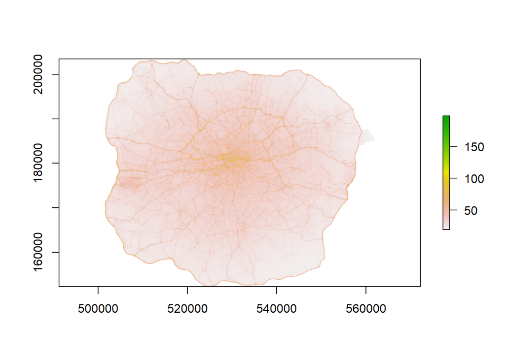

```r
plot(no2_2013)
```

If you wanted to add your `route` to the same map, you could do something like this. It’s a little small, but you can figure out how to improve that later.

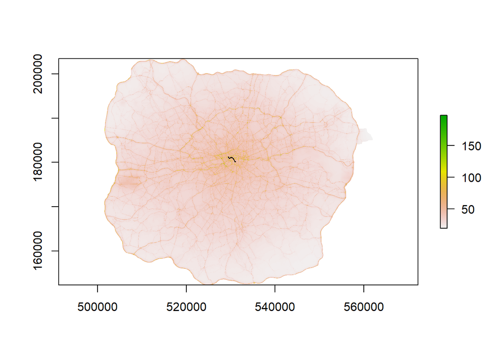

```r
plot(no2_2013)                                      # Plot the NO2
plot(st_geometry(st_transform(route,27700)), add=T) # transform the route to CRS 27700, extract the geometry', and add it to the above plot
```

## Extract concentrations for the route

#### Preparing the route

We have to decide how our exposure is going to be calculated. Do we want the average concentration along the route? The maximum? The minimum? The London Hybrid Exposure Model has temporal scale of one minute, so we’ll calculate it on a minute by minute basis, then we can decide after whether to take the mean or some other measure.

If we want to calculate exposure per minute, we are going to need to split the line that represents our journey into a point per minute. We also need to change our `route` into the same CRS as the air quality `no2_2013` data.

```r
route                 <- st_transform(route, 27700)                     # Change the route CRS to the same as the raster

route_points          <- st_line_sample(route,
                                round(route$duration/60,0),
                                type = 'regular')                       # sample regular points along the route
```

Look up the `st_line_sample()` function of the `sf` package. What other `type` option is available? [Put your answer into the form](https://goo.gl/forms/ndJZ1hAgCviAPgsG3).

Now we will turn the multipoint object into a points object (don’t worry too much about what this means for now), and we will add the minutes as a field of the data.

```r
route_points          <- st_cast(route_points, "POINT")                 # Turn multipoint object to points

route_points          <- st_sf(minute = 1:round(route$duration/60,0),   # Add the minutes as a field of the object
                               geom = route_points)
```

Let’s plot out the `route` data and see what it looks like now.

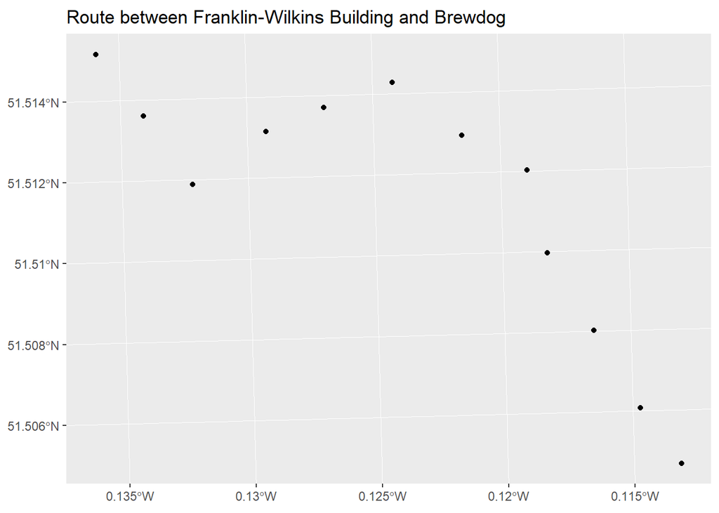

```r
ggplot() +
  geom_sf(data = route_points) +
  ggtitle('Route between Franklin-Wilkins Building and Brewdog')
```

#### Extract concentrations

For each point of the route we are now going to find out the NO2 concentration at that location using the `extract()` function from the `raster` library. We will convert the points from a sf type to a sp type ‘on the fly’, as the `extract()` function does not work with sf objects yet.

```r
route_points$no2 <- raster::extract(no2_2013,
                                    as(route_points, 'Spatial')@coords)
```

The data now looks like this - great!

```r
route_points
```

```
## Simple feature collection with 12 features and 2 fields
## geometry type:  POINT
## dimension:      XY
## bbox:           xmin: 529443.7 ymin: 180103.2 xmax: 531054.6 ymax: 181228.8
## epsg (SRID):    27700
## proj4string:    +proj=tmerc +lat_0=49 +lon_0=-2 +k=0.9996012717 +x_0=400000 +y_0=-100000 +ellps=airy +towgs84=446.448,-125.157,542.06,0.15,0.247,0.842,-20.489 +units=m +no_defs
## First 10 features:
##    minute                      geom       no2
## 1       1 POINT (531054.6 180103.2)  93.86069
## 2       2 POINT (530941.2 180255.2) 109.30760
## 3       3 POINT (530813.8 180469.6) 109.09560
## 4       4 POINT (530685.1 180683.2) 112.08860
## 5       5 POINT (530629.2 180910.8) 109.41330
## 6       6 POINT (530449.6 181006.3)  57.71885
## 7       7   POINT (530258 181152.5)  62.13323
## 8       8 POINT (530070.2 181082.1)  60.35130
## 9       9   POINT (529911 181016.7) 137.72350
## 10     10 POINT (529710.4 180870.8)  82.11654
```

At this point we could make a graph of the exposure during the journey like this.

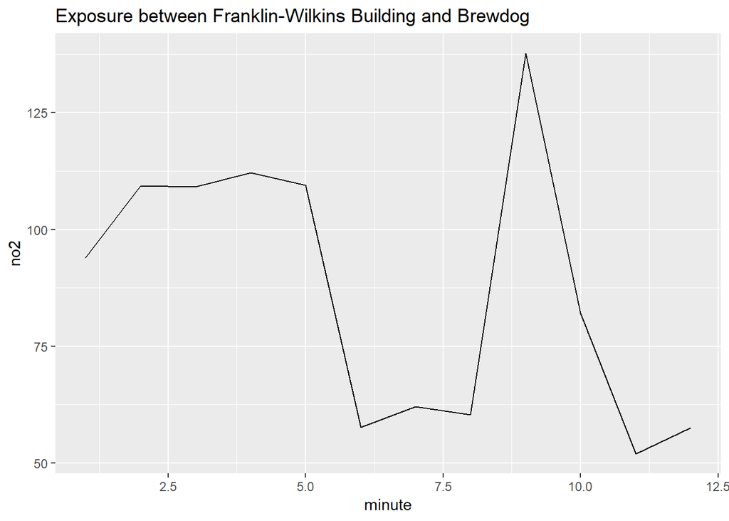

```r
ggplot(route_points, aes(minute, no2)) +
  geom_path() +
  ggtitle('Exposure between Franklin-Wilkins Building and Brewdog')
```

## Microenvironmental modelling

Finally, the concentrations we have extracted from the air quality model are representative of air outdoors at the point locations. But if the person was inside a vehicle, for example a car, then the air would be different (but influenced by) the air outside the car. There are different ways of modelling this difference between the outdoor air and the indoor (in-car) air. A simple way is to use an indoor/outdoor (I/O) ratio. A recent literature review estimated that NO2 concentrations inside vehicles are typically around 77% of the outdoor air. So if we wanted, we could reflect this in our exposure model by multiplying the outdoor concentrations by 0.77.

```r
route_points$incar_no2 <- route_points$no2 * 0.77 # make a new variable called 'incar_no2' and put the no2 value * 0.77 into it.
```

If you were going to look at different transport modes, you would need to look for different ratios of course.

## Make a map

Earlier we make a quick map of NO2 concentrations in London, and plotted the route on it. Let’s try and make an exposure map now, using the `ggplot2` package again. We will plot out the NO2 data for our area, and put the points on top of that.

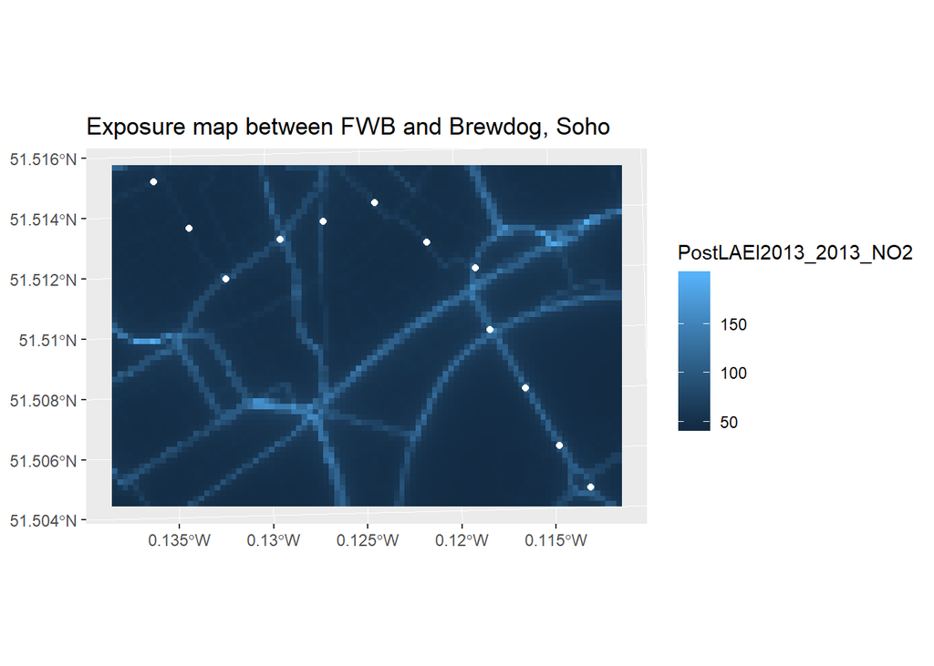

```r
no2_2013_crop     <- crop(no2_2013, extent(route) + 100) # For our map we only need the NO2 data for a small area, not the whole of London
# If you are on a Mac you might need to do this command instead: no2_2013_crop <- crop(no2_2013, extent(as(route, 'Spatial'))+100)

no2_2013_crop     <- rasterToPolygons(no2_2013_crop)      # Converting the raster file to polygons so that we can use this data with the ggplot2 library

no2_2013_crop     <- st_as_sf(no2_2013_crop)              # Converting the sp polygons to a sf polygons type, again, it's better for plotting with ggplot2 this way

ggplot() +
  geom_sf(data=no2_2013_crop, aes(fill = PostLAEI2013_2013_NO2), colour=NA) +
  geom_sf(data=route_points, colour='white') +
  ggtitle('Exposure map between FWB and Brewdog, Soho') +
  theme(panel.background = element_rect())
```

Note the line `theme(panel.background = element_rect())` in the code above. There are various options that you can use here to change the look and feel of your map. You should use the [ggplot2 reference manual](https://ggplot2.tidyverse.org/reference/theme.html) and search Google to find more details. We’re not expecting you to be an expert at any of this during the module, but some idea would be good.

## Task / homework

I would like you to make and send to me by 5pm tomorrow, a PNG file that is as similar to the below as you can manage, aswell as the `ggplot()` code you used to create it. If you want to work in pairs, as a group, or even as a whole class that’s fine; this isn’t assessed.

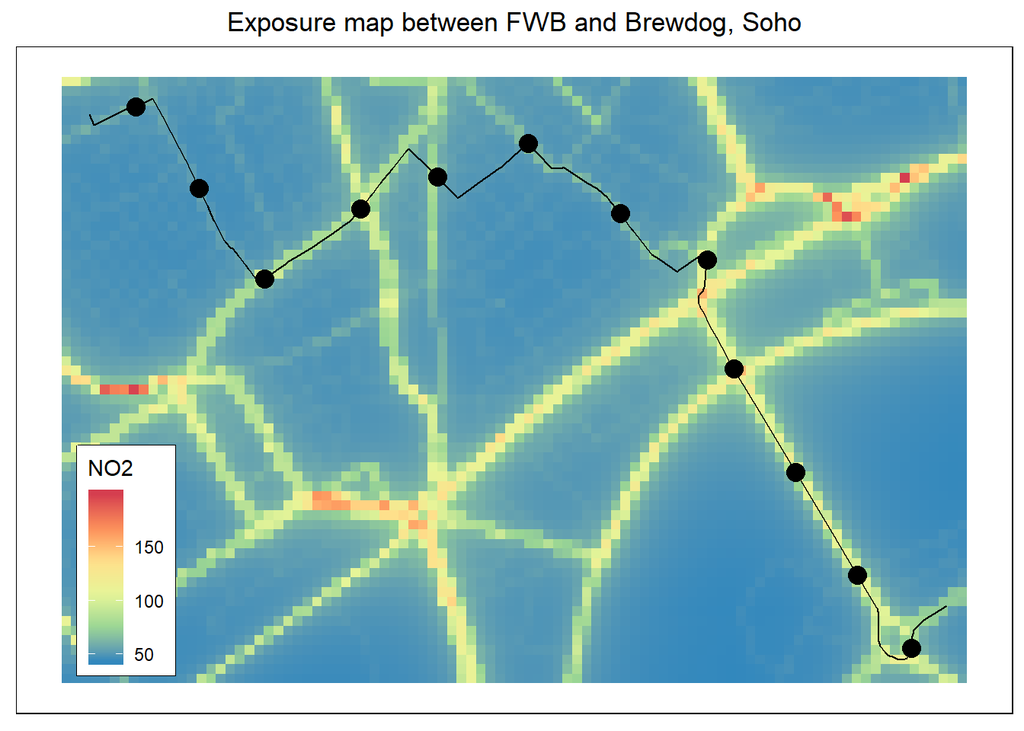